# はじめに

### 計算グラフ

先程実施した単純パーセプトロンの学習と同様で、学習というのは重みやバイアスといった変数の値を調整する作業になります[^5]。で、変数を調整するための元ネタとして、単純パーセプトロンでは入力値を、今からやろうとしている逆誤差伝播学習法では微分を使うんでした。

この微分には、どのような計算がなされたのかという情報が必要なんだそうです。そういえば、はるか昔、私が高校時代にぶん投げた数学の教科書には「f(x,y)=*小難しい式*のとき、xで偏微分せよ」とか書いてあったような気がします。「どんな式かは分からないけど、フィーリングでいい感じで偏微分してちょうだいよ」というわけにはいかないみたい……。

だから、TensorFlowには計算式を定義する機能があります。計算式の定義は簡単で、TensorFlowが提供する演算子や関数と、変数作成機能を使って普通にプログラミングしていくだけ。具体的に、足し算を例に試してみましょう。

```python
import tensorflow as tf

a = tf.Variable(1)
b = tf.Variable(2)
c = a + b
d = tf.Variable(3)
e = c + d

print(e)
print(e.op)
```

```python
name: "add_12"
op: "Add"
input: "add_11"
input: "Variable_19/read"
attr {
  key: "T"
  value {
    type: DT_INT32
  }
}
```

うん、なんとなく、どのような計算をするのかを表現していますな。面白いのは、一つ目の`input`の値です。他の計算式（変数`c`が指し示す計算式）を指しています。つまり、計算式をグラフ形式で表現しているわけ。このような計算を表現するグラフを、計算グラフと呼びます。

で、ここまでで定義した計算グラフを実行するには、TensorFlowのセッションが必要です。こんな感じ。

```python
# セッションを作成します。
with tf.Session() as session:
    # TensorFlowのVariableは、明示的に初期化しなければなりません。
    session.run(tf.global_variables_initializer())

    # 計算グラフを実行します。
    result = session.run(e)

    # 計算結果を表示します。
    print(result)
```

ここまでやって、やっと計算の実行結果である`6`が表示されます……。

2段階に分かれているので面倒に感じますけど、単純パーセプトロンのときみたいに学習のためのロジックを手書きするより遥かに簡単なので、我慢してください。そもそも、上の例のような順方向の計算だけなら、TensorFlowを使わずに普通に組めばよいわけですしね。

### テンソル

まぁ、プログラミングのレベルでぶっちゃけていえば、テンソルってのは固定長の多次元の配列です。値そのものを表すスカラー（1や2.0）とかベクトル（平面座標`(x, y)`や立体座標`(x, y, z)`）とか行列（3次元グラフィックスの座標変換で使うアレ）とかを統一的に扱う仕組みにすぎないんですよ。なお、スカラーはランク0、ベクトルはランク1、行列はランク2のテンソルと表現されます。あと、たとえばカラー画像だと、そのランクは3になります。Y座標を指定すると横1ライン分のテンソルになって、そのテンソルにX座標を指定すると1ドット分のテンソルになって、そのテンソルに色（RGBA）を指定したら明るさというランク0のテンソルになる、このように、3段階の構造になっていますからね。と、まぁ、普段プログラミングでやっている内容と変わりませんから、あまりテンソルを嫌わないでやってください。

で、なんでこのテンソルが深層学習で重要かというと、多層パーセプトロンをテンソルの演算として表現できるためです。単純パーセプトロンのとこでやった`sum(x * weight for x, weight in zip(xs, weights)`は、xsというテンソル（この場合はランク1なのでベクトル）とweightsというテンソル（同様にベクトル）に対するドット積（もしくは内積）と呼ばれる演算に相当します。だから、NumPyを使うなら上のコードは`np.dot(xs, weights)`とか`np.inner(xs, weights)`とか`np.matmul(xs, weights)`とかのように、とても簡単に書けます。

パーセプトロンを複数個並べる場合だって、とても簡単です。たとえばパーセプトロンが2個なら、以下のような感じ。

```python
import numpy as np

x = np.array([1, 2])            # 変数名がxsではなくてxなのは、テンソルはスカラーもベクトルも表現できちゃうので複数形の意味がなくなるため。
w = np.array([[3, 4], [5, 6]])  # 数学の本ではベクトルは太字にするみたいで、それを表現するために変数名を大文字にする数学プログラマーもいますけど、
b = np.array([7, 8])            # そこまで標準から外れるのは嫌なので、単数形でお茶を濁しました……。

print(np.maximum(np.matmul(x, w) + b, 0))  # [20 24]が表示されます。
```

wとbのランクを1つ上げて、最初の添字の要素数を2にするだけです。私のようなビジネス・アプリケーションのプログラマーだとパーセプトロンのインスタンスを複数個作成してリストに格納して`for`文等でそれぞれを呼び出すというやり方のほうが馴染み深いので変に感じますけど、こんなやり方もあるんですな。

ともあれ、このやり方なら、多層パーセプトロンの全てを計算式、つまりは計算グラフとして表現できることになります[^6]。計算式が分かれば逆誤差伝播学習法が使えるわけで、これならもうすぐに深層学習できちゃう。

### tf.contrib.layersとtf.nn、tf.train、tf

というわけで、機械学習可能な多層パーセプトロンをテンソルを使用する計算グラフとして定義……するのは、式がやたらと長くなるのでとても面倒くさいんです。だから、TensorFlowは深層学習の計算グラフを定義するための便利機能を提供しています。

まずは、`tf.contrib.layers`。`tf.contrib.layers`は、ニューラル・ネットワーク（多層パーセプトロンは、ニューラル・ネットワークの一つ）の層を生成する機能を提供します。たとえば、`tf.contrib.layers`の中の`fully_connected()`という関数は、多層パーセプトロンの層を一つ、まるっと作成してれます（どうしてこんな変な名前になっているかというと、後述する畳み込み層との対比で全結合層と呼ばれるようになったため……。深層学習とか数学は、歴史が長いので命名がバラバラで涙が出ちゃう）。`linear()`は活性化関数を含まない`fully_connected()`で、一番最後の層、出口で使います。

`tf.nn`は、ニューラル・ネットワーク特有の処理を提供します。たとえば、少し前で述べたReLUが`relu()`として定義されています（`tf.contrib.layers.fully_connected()`等が勝手にReLUしてくれるので、使う機会は少ないですけど）。逆誤差伝播学習法での伝播していく大本の誤差はクロス・エントロピーと呼ばれる計算で出すとよいとされているのですど、そのクロス・エントロピーを計算してくれる`sparse_softmax_cross_entropy_with_logits()`なんてのもあります。あと、今回のように複数の選択肢の中のどれかを答えるような場合は、最後に「1」とか「2」と出力するのではなくて、「0かなーと思う数値は0.28」、「1だと思う数値は5.97」のように、10個の数値を出力する方式を採用します。そのような出力の場合に正解したかどうかを確認してくれる`in_top_k()`という関数もあります。

`tf.train`という、訓練の際に役立つパッケージもあります。単純パーセプトロンのところで学習率について説明しましたけど、深層学習ではこの学習率の設定がやたらとシビアなんですよ。`tf.train`の中には、この学習率をいい感じで自動設定（初期値を設定してくれるだけじゃなくて、適宜変更してくれる！）しながら訓練してくれる`AdamOptimizer`というクラスがあります。

で、これらのパッケージに含まれない基礎的な機能は、`tf`パッケージが提供します。`placeholder()`という、入力値や正解ラベルなどの、学習で調整されるわけでも定数でもない入れ物を作る関数とか、変数の初期化のための`global_variable_initializer()`とか、平均を計算する`reduce_mean()`とかね。

### TensorFlowを使用した、多層パーセプトロン

はい、ついに必要な知識が揃いました。TensorFlowで多層パーセプトロンを作成して、逆誤差伝播学習法で訓練してみましょう。

そのためのコードは、こんな感じ。

```python
import tensorflow as tf

from tensorflow.examples.tutorials.mnist import input_data

# MNISTデータを取得します。
train_data_set, validation_data_set, test_data_set = input_data.read_data_sets("MNIST_data/")

# 画像と正解ラベルを入れる変数を作成します。
images = tf.placeholder(tf.float32, (None, 784))
labels = tf.placeholder(tf.int32, (None,))

# ニューラル・ネットワークを定義します。TensorFlowでは、ニューラル・ネットワークの出力はlogitと呼びます。
logits = tf.contrib.layers.linear(tf.contrib.layers.fully_connected(images, 128), 10)

# logitとlabelsの誤差を計算します。TensorFlowでは、lossと呼びます。
loss = tf.reduce_mean(tf.nn.sparse_softmax_cross_entropy_with_logits(labels=labels, logits=logits))

# どのように訓練するのかを定義します。lossが小さくなるように、学習率を自動で設定してくれるAdamOptimizerで訓練します。
train = tf.train.AdamOptimizer().minimize(loss)

# 正解率を計算します。
accuracy = tf.reduce_mean(tf.cast(tf.nn.in_top_k(logits, labels, 1), tf.float32))

# セッションを作成します。
with tf.Session() as session:
    # tf.contrib.layersで変数を使用しているので、初期化します。
    session.run(tf.global_variables_initializer())

    # 3000回、訓練します。
    for i in range(3000):
        # 1回の訓練では、100個のデータを使用します。
        images_value, labels_value = train_data_set.next_batch(100)
        session.run(train, feed_dict={images: images_value, labels: labels_value})

        # 精度の推移を知るために、100回に一回、訓練データと検証データでの精度を出力します。
        if i % 100 == 0:
            print("accuracy of train data: {0}".format(session.run(accuracy, feed_dict={images: images_value, labels: labels_value})))
            print("accuracy of validation data: {0}".format(session.run(accuracy, feed_dict={images: validation_data_set.images, labels: validation_data_set.labels})))

    # テスト・データでの精度を出力します。
    print("accuracy of test data: {0}".format(session.run(accuracy, feed_dict={images: test_data_set.images, labels: test_data_set.labels})))
```

MNISTのデータを取得する部分は、前に述べた通り。で、MNISTのデータをそのまま計算グラフに含めてしまうと同じ計算を繰り返して実施することになってしまいますから、`tf.placeholder()`を経由させます。`tf.placeholder()`の第一引数は要素の型（MNISTの画像のデータは0.0〜1.0なので`tf.float32`、正解ラベルは1とか2なので`tf.int32`）、第二引数は要素の数です。で、この第二引数、画像は28x28=784個になるのですけど、その前に`None`と書かれています。これは、「バッチ学習」に対応するためなんですよ。

バッチ学習というのは、複数のデータを使用してバッチ的に学習する方式です。データ一つだけで訓練をすると、近視眼的になるので右往左往しちゃって、なかなか学習が進まないんです。だから、複数のデータをまとめて計算して、その平均を誤差として扱うわけ。で、このバッチ学習のためにデータをまとめる数をあとから指定できるように、コードでは`None`を指定しています。

ニューラル・ネットワークの定義は、`tf.contrib.layers.fully_connected()`の結果を`tf.contrib.layers.linear()`しているだけ。深層学習って、ライブラリを使うならば、計算式を知らなくても余裕なんですな。で、TensorFlowではニューラル・ネットワークの計算グラフを`logits`という変数に格納する流儀になっている（理由は調べても分からなかった……）ので、それに従っています。

`fully_connected()`は前項で述べたように多層パーセプトロンの層の生成で、`linear()`は活性化関数を含まない多層パーセプトロンの層の生成です。引数は、入力となる計算グラフと生成したいパーセプトロンの数。ちなみに最後を`linear()`にしているのは、どのような出力にするのかを後から選べるようにするためです。どの数字かを当てるだけならそのままでよいですし、1の可能性が83.4%、2の可能性が13.2%のように表示したい場合は`tf.nn.softmax()`してあげてください。今回のように逆誤差伝播学習法で学習したいなら、誤差計算のところのコードのように`tf.nn.sparse_softmax_cross_entropy_with_logits()`してあげればよいでしょう。バッチ学習を採用しているので、上のコードでは各データの誤差を平均するために`tf.reduce_mean()`しています。

次、訓練方法。学習率を考えるのは面倒なので`tf.train.AdamOptimizer`を使って全て任せることにして、誤差を最小化するように訓練するので`minimize()`を使用しています。あと、どの程度正解したかを確認するための`accuracy`という計算グラフも定義しておきます。`tf.nn.in_top_k()`は、`logit[label]`が、第三引数で指定した値の順位に収まっているかを調べます。`logits`が`[3, 2, 1]`で`label`が`2`の場合、第三引数が`1`や`2`なら`False`、`3`なら`True`になるわけですね。で、バッチ学習なので結果は`True`や`False`のベクトルになって、Pythonの`True`は1、`False`は0として扱えるので、`tf.float32`にキャストして`tf.reduce_mean()`で平均を取れば正解率となるわけ。

以上で計算グラフの定義は完了なので、残るは訓練だけ。セッションを作成して、変数を初期化して、バッチ学習用のデータを取得して、訓練用の計算グラフである`train`を実行します。`train`が参照している`loss`が参照している`logits`の計算グラフには`images`と`labels`が含まれていて、それらの値が決まらないと計算を開始できませんから、名前付き引数の`feed_dict`でバッチ学習用のデータを渡しています。

で、これで必須の作業は終わりなのですけど、訓練でどの程度正解できるようになったかを知りたいですよね？ だから、上のコードでは時々正解率を表示するようにしています。この正解率は、訓練データと検証データ、最後にはテスト・データの場合で表示しています。何度も似た情報を出力しているのは、訓練データに特化した学習（過学習といいます）をしてしまうのを避けるため。たとえばある問題集の解答を丸暗記すればその問題集には全問正解できるけれど、それでは他の問題集の問題は解けないので試験に落ちちゃって困っちゃう。訓練には使用していない検証データの正解率も調べておけば、訓練データでの正解率は向上しているけど検証データでの正解率は向上しないような場合に、過学習に陥ったと考えることができるわけ。検証データに加えてテスト・データでも正解率を出しているのは、ニューラル・ネットワークを調整（パーセプトロンの数を増やすとか、層を追加するとか）する際に、たまたま検証データに最適化した調整をしてしまうのを防ぐためです。検証データを使用して過学習を防いで、そのニューラル・ネットワークが本当に役に立つのかをテスト・データで検証するわけですな。

はい、これで解説は終わり！ プログラムを実行しましょう。少し時間がかかりますけど、最後に以下のような出力が出ます（重みやバイアスの初期値はランダムなので、結果は正確に同じにはなりません。でも、大体同じ値になるはず）。

```python
accuracy of train data: 0.9900000095367432
accuracy of validation data: 0.9761999845504761
accuracy of test data: 0.9747999906539917
```

テスト・データでの正解率が97.5%ってのは、なかなか良い結果だと思いませんか？

## 畳み込みニューラルネットワーク

でもね、もっと正解率を向上できるんです。そう、畳み込みニューラル・ネットワークならね。

### 畳み込み？

で、その畳み込みニューラル・ネットワークの「畳み込み」ってのは、いったい何なのでしょうか？

畳み込みは、数学から考えずに、画像処理から考えると簡単に理解できます。画像処理といえばOpenCVというライブラリが思い浮かびますよね？ この「OpenCV」に「畳み込み」を加えてGoogle検索すると、OpenCVの画像フィルタリングの機能がリスト・アップされます。このフィルタリングこそが、実は畳込みニューラル・ネットワークにおける「畳込み」なんですよ。

さっそく、フィルタリング（畳み込み）をやってみましょう。

```python
import cv2  # 動かす前に、pip install opencv-pythonしておいてください。
import matplotlib.pyplot as plot  # 動かす前に、pip install matplotlibしておいてください。
import numpy as np

# 画像を読み込んで、白黒に変換します。
image = cv2.cvtColor(cv2.imread('./images/lena.jpg'), cv2.COLOR_BGR2GRAY)

# とりあえず、何もしないで表示します。
plot.imshow(image)
plot.show()

# フィルタリング（畳み込み）します。
filtered_image = cv2.filter2D(image, -1, np.array([[-1, -1, -1],
                                                   [-1,  8, -1],
                                                   [-1, -1, -1]]))

# フィルタリングした（畳み込んだ）結果を表示します。
plot.imshow(filtered_image)
plot.show()
```

上のコードを実行すると、まずは読み込んだ以下の画像が表示されます。

[figure not shown]

この画像を閉じると、続いてフィルタリング（畳み込み）処理が実行され、たったこれだけのコードなのに、以下の輪郭が抽出された画像が表示されます。

[figure not shown]

なんかスゴイ！ で、コードが短いのに輪郭抽出などという高度な処理ができるのは、OpenCVが`cv2.filter2D()`の中でとてもすごい処理をやっているから……ではありません。実は、`cv2.filter2D()`でやっているのは、第3引数のテンソルを掛け合わせて足し算しているだけなんですよ。

コードにすると、こんな感じ。

```python
import cv2  # 動かす前に、pip install opencv-pythonしておいてください。
import matplotlib.pyplot as plot  # 動かす前に、pip install matplotlibしておいてください。
import numpy as np

image = cv2.cvtColor(cv2.imread('./images/lena.jpg'), cv2.COLOR_BGR2GRAY)

# 3x3でフィルタリング（畳み込み）しますので、-1と+1できるように、元画像を1ドットずつ大きくします。
scaled_image = cv2.copyMakeBorder(image, 1, 1, 1, 1, cv2.BORDER_CONSTANT, 0)

# フィルタリング（畳み込み）先の画像を用意します。
filtered_image = np.zeros(image.shape)

# フィルタリング（畳み込み）。
for i in range(filtered_image.shape[0]):
    for j in range(filtered_image.shape[1]):
        y = i + 1  # フィルタリング（畳み込み）元の位置は、1ドット右になります。
        x = j + 1  # フィルタリング（畳み込み）元の位置は、1ドット下になります。

        # フィルタリング（畳み込み）のドットを設定します。
        filtered_image[i, j] = (scaled_image[y - 1, x - 1] * -1 +
                                scaled_image[y - 1, x    ] * -1 +
                                scaled_image[y - 1, x + 1] * -1 +
                                scaled_image[y    , x - 1] * -1 +
                                scaled_image[y    , x    ] *  8 +
                                scaled_image[y    , x + 1] * -1 +
                                scaled_image[y + 1, x - 1] * -1 +
                                scaled_image[y + 1, x    ] * -1 +
                                scaled_image[y + 1, x + 1] * -1)

# 画像なので、0〜255の間に限定します。
filtered_image[filtered_image <   0] = 0
filtered_image[filtered_image > 255] = 255

# 表示します。
plot.imshow(filtered_image)
plot.show()
```

で、上のコードのドットを設定しているところの掛け算して足し合わせるという処理は、単純パーセプトロンのところでやったような気がしませんか？ この手の処理は、たしかテンソルを使った簡潔な表現が可能でしたよね？ 書き換えてみましょう。

```python
w = [-1, -1, -1, -1, 8, -1, -1, -1, -1]

# フィルタリング（畳み込み）。
for i in range(filtered_image.shape[0]):
    for j in range(filtered_image.shape[1]):
        # フィルタリング対象のデータを抽出します。
        x = np.reshape(scaled_image[i:i + 3, j:j + 3], (9,))

        # 内積を求めて、フィルタリング（畳み込み）のドットを設定します。
        filtered_image[i, j] = np.matmul(x, w)
```

あらら。入力値の一部だけを使う点を除けば、これってパーセプトロンにそっくりじゃあないですか！ で、パーセプトロンで重みを変更したら異なる場合の判断に使えたのと同様に、フィルタリング（畳み込み）も様々な目的に使えます。たとえば、`w = [3, 0, -3, 3, 0, -3, 3, 0, -3]`に変更してみると……

[figure not shown]

ほら、縦方向の線の抽出が可能になりました。もう少し工夫すれば、手書き文字認識に適したフィルタリング（畳み込み）ができるかもしれません。たとえば、角を強調するとか、交点を強調するとかね。

どのようなテンソルを与えれ手書き文字認識に適したフィルタリング（畳み込み）になるか分からない、そもそもフィルタリング（畳み込み）で何を強調すればよいのか分からない……という問題は、今までやってきたのと同様に、逆誤差伝播学習法による学習で解決しちゃえばよいというわけ。

### プーリングとドロップアウト

あと、畳込みのあとに実施すると有効なテクニックとして、プーリングがあります。他に、いろいろなニューラル・ネットワークで有効なのだけどタイミングがなくて説明しそこねたテクニックとして、ドロップアウトがあります。畳込みニューラル・ネットのプログラミングをはじめる前に、この2つのテクニックを説明させてください。

プーリングとは、複数のデータをまとめる処理になります。たとえば、縦2ドット横2ドット、合計4ドット分の4つのデータを1つのデータに変換します。変換の方法として、昔は平均を取るのがよく使われていたみたいなのですけど、最近は、最大値を選択するマックス・プーリングが主流みたい。

このプーリングの利点としては、たとえば縦2ドット横2ドットでプーリングした場合に、入力画像における1ドットのズレを解消できることが挙げられます。座標(0, 0)が畳み込みで反応した場合も、座標(1, 1)が畳み込みで反応した場合も、プーリングすれば結果は同じになりますからね。たった1ドットと侮らないでください。畳み込みは繰り返し実施するとその効果が高まるらしいので、一般に何層か積み重ねます。畳み込み→縦横2ドットでのプーリングが2層なら元画像での4×4ドット、もう一層あれば8×8ドットの中に、特徴的な箇所が含まれていれば大丈夫になるんですよ（まぁ、それでもたった8ドットなのですけど、無いよりはマシ）。

プーリングには、データの質を保ったままで量を減らせるという効果もあります。畳込みで抽出したい特徴が10ある場合、結果は10枚の画像になるので、データ量が10倍になってしまうわけです。でも、その後に縦2ドット横2ドットでプーリングすれば、画像の大きさは縦も横も1/2なので1/4になり、これなら元の2.5倍のデータ量におさまります。マックス・プーリングなら畳み込んだときに最も強く反応したデータが残りますから、プーリングでデータ量を減らしても特徴は保たれているでしょう。

次、ドロップアウト。これは、ニューラル・ネットワークの構成要素（ニューロン）を、一時的に一定割合で削除してしまうというテクニックです。

ドロップ・アウトをやると、入力が欠けた状態でも正しく判断できるようにするために、データの細かな特徴ではなく、大きな特徴を学習するようになるみたい。テレビを見て、今受信しているのはどの放送局かを当てる人工知能で考えてみましょう。もしテレビの画面全体が正しく表示されているなら、右上に表示されている放送局のマークを見るだけで正解できます。だから、画面の他の部分は見ずに、右上だけを凝視して回答するようになってしまうでしょう。でも、もしテレビ画面の半分ぐらいが映らないなら？ その映らない範囲が、ランダムに変わるとしたら？ これなら、画面全体をまんべんなく見て、大きなお友達向けのアニメが流れているからTokyo MXかなぁと答えられる、より汎用的な人工知能に育ってくれるというわけです。

### tf.contrib.layers再び

さて、前節で多層パーセプトロンを作成したときは、`tf.contrib.layers.fully_connected()`を使用しました。畳み込みニューラル・ネットワークの作成では、同様に`tf.contrib.layers.conv2d()`を使用します。マックス・プーリングは`tf.contrib.layers.max_pool2d()`。ドロップアウトも、`tf.contrib.layers.dropout()`を呼び出すだけで実現できます。モーレツに楽ちんですな。

もう少し。MNISTのテンソルは1次元なのですけど、`tf.contrib.layers.conv2d()`が生成する畳み込みニューラル・ネットワークの処理対象のテンソルは2次元です。だから、`tf.reshape()`での変換が必要です。逆向きの変換は、`tf.flatten()`で実施できます。

### TensorFlowを使用した、畳み込みニューラル・ネットワーク

では、待ちに待った畳込みニューラル・ネットワークをやってみましょう。コードは、こんな感じ。

```python
import tensorflow as tf

from tensorflow.examples.tutorials.mnist import input_data

# MNISTデータを取得します。
train_data_set, validation_data_set, test_data_set = input_data.read_data_sets("MNIST_data/")

# 画像と正解ラベル、トレーニング中かをを入れる変数を作成します。
images = tf.placeholder(tf.float32, (None, 784))
labels = tf.placeholder(tf.int32, (None,))
is_training = tf.placeholder_with_default(False, ())

# ニューラル・ネットワークを定義します。TensorFlowでは、ニューラル・ネットワークの出力はlogitと呼びます。
logits = tf.reshape(images, (-1, 28, 28, 1))
logits = tf.contrib.layers.conv2d(logits, 32, 5)
logits = tf.contrib.layers.max_pool2d(logits, 2)
logits = tf.contrib.layers.conv2d(logits, 64, 5)
logits = tf.contrib.layers.max_pool2d(logits, 2)
logits = tf.contrib.layers.flatten(logits)
logits = tf.contrib.layers.fully_connected(logits, 128)
logits = tf.contrib.layers.dropout(logits, is_training=is_training)
logits = tf.contrib.layers.linear(logits, 10)

# logitとlabelsの誤差を計算します。TensorFlowでは、lossと呼びます。
loss = tf.reduce_mean(tf.nn.sparse_softmax_cross_entropy_with_logits(labels=labels, logits=logits))

# どのように訓練するのかを定義します。lossが小さくなるように、学習率を自動で設定してくれるAdamOptimizerで訓練します。
train = tf.train.AdamOptimizer().minimize(loss)

# 正解率を計算します。
accuracy = tf.reduce_mean(tf.cast(tf.nn.in_top_k(logits, labels, 1), tf.float32))

# セッションを作成します。
with tf.Session() as session:
    # tf.contrib.layersで変数を使用しているので、初期化します。
    session.run(tf.global_variables_initializer())

    # 3000回、訓練します。
    for i in range(3000):
        # 1回の訓練では、100個のデータを使用します。
        images_value, labels_value = train_data_set.next_batch(100)
        session.run(train, feed_dict={images: images_value, labels: labels_value, is_training: True})

        # 精度の推移を知るために、100回に一回、訓練データと検証データでの精度を出力します。
        if i % 100 == 0:
            print("accuracy of train data: {0}".format(session.run(accuracy, feed_dict={images: images_value, labels: labels_value})))
            print("accuracy of validation data: {0}".format(session.run(accuracy, feed_dict={images: validation_data_set.images, labels: validation_data_set.labels})))

    # テスト・データでの精度を出力します。
    print("accuracy of test data: {0}".format(session.run(accuracy, feed_dict={images: test_data_set.images, labels: test_data_set.labels})))
```

多層パーセプトロンのコードとの違いは、`is_training`というドロップアウト制御用の変数が追加されたことと、ニューラル・ネットワークの定義部分が異なっているところだけです。

`tf.contrib.layers.conv2d()`に渡すテンソルは、[バッチ数, 高さ, 幅, チャンネル数]という形です。で、バッチ数は実行時に指定したいから`-1`にします（`placeholder()`のときは`None`だったのに、`reshape()`では`-1`なんですよ。このような不整合は勘弁して欲しい……）。MNISTのデータは高さも幅も28。白黒なので、チャンネル数は1です（カラーなら赤と緑と青で3チャンネル。透明度が加わったRGBAなら4チャンネル）。というわけで、`tf.reshape()`の第二引数は`(-1, 28, 28, 1)`となります。あと、`reshape()`の結果を`conv2d()`の引数にして……と書くと横方向に際限なく長くなってしまうので、上のコードでは一時変数を使用して縦に並べました（F#の`|>`やClojureの`->`みたいな、左から右にコードを書く仕組みが欲しい……。まぁ、どうしようもないけど）。

`tf.contrib.layers.conv2d()`の引数は、第二引数が出力するチャンネルの数で、第三引数がフィルタリング（畳み込み）するフィルターの大きさです。チャンネルの数には、画像の場合のような制約（画像は白黒かカラーか透明度付きカラーだけなので、チャンネル数は1か3か4のどれかしか選べない）はありません。抽出したい特徴の数を、自由に指定してください（現場では、とりあえず適当な数を設定して、適当に増減させて調節することになります）。フィルターのサイズは、抽出したい特徴の大きさになります（こちらも、現場では当てずっぽうで設定してあとで調整します）。

`tf.contrib.layers.max_pool2d()`の引数は、データをまとめる大きさです。`2`を指定すれば、縦横2ドットのデータを一つにまとめます。`conv2d()`と`max_pool2d()`は、複数回繰り返すと大きく性能が上がるらしいので、上のコードでは2回繰り返してみました。

で、畳み込みやプーリングの結果は、やっぱり画像になります。これをそのまま出力したのでは手書き文字認識にはなりませんから、畳込みの結果を入力にして、多層パーセプトロンをつなげます。多層パーセプトロンの入力は1次元のデータなので、`tf.contrib.layers.flatten()`した後に`tf.contrib.layers.fully_connected()`しています。

あとは、精度が高くなるという噂を信じて`tf.contrib.layers.dropout()`を入れて、`tf.contrib.layers.linear()`で締めれば終わりです。そうそう、`dropout()`は、名前付き引数の`is_training`が`True`ならばニューラル・ネットワークの一部を削除し、`False`ならば削除しません。訓練のときは`is_training=True`、正解率を確認するときは`is_training=False`にしたいので、`is_trainning`は`tf.placeholder_with_defrault()`でデフォルト値を`False`にして作成し、訓練のときだけ`feed_dict`を通じて値を設定するようにしています。

以上、これでコードの解説は終わり！ プログラムを実行してみましょう。かなり長い時間がかかりますから、トイレに行ったりコーヒー飲んだりしてみてください。で、その結果はどうかというと……

```python
accuracy of train data: 1.0
accuracy of validation data: 0.9911999702453613
accuracy of test data: 0.9919999837875366
```

テスト・データでの正解率が99%を超えて、99.2%になりました！ 深層学習って、スゴイですな。

# プログラムの作成

このようにスゴイ深層学習を、実際のプログラムで試してみたくなりませんか？ 私は試してみたくなっちゃったので、今回は、ロボットに一般物体認識させるプログラムを作ってきました。

で、その作ってきたソース・コードは、皆様が深層学習するときのテンプレートとして使用できるんじゃないかなーと考えてています。本章で紹介するソース・コードを少し修正するだけで、皆様が深層学習でやりたいことを実現できるんじゃないかなーと。

## ソース・コードの取得方法

そんなことを言われても、現物を見なければ信用できない？ おっしゃる通りですね。ソース・コードは[GitHub](https://github.com/tail-island/jellyfish-eye/)で管理していますので、[Git for Windows](https://git-for-windows.github.io/)をセットアップして、以下のコマンドでダウンロードしてみてください。

```bash
> cd TensorFlow  # 「2. インストール」で作成した、TensorFlow用の仮想環境
> git clone https://github.com/tail-island/jellyfish-eye.git
```

なお、プロジェクト名のjellyfish-eyeは、一部のクラゲは高機能な目を持っていて、脳がないにもかかわらず目で見た情報を処理して活用しているらしいことに由来しています。脳を持たないロボットがセンサーの情報にもとづいて自律行動しちゃうぜって感じですね。

## Pythonのパッケージ

Pythonでは、ファイルがパッケージの単位になります。`./aaa.py`の中から`./bbb.py`に含まれる関数を使う際には、`import bbb`してあげなければならないわけですね。

今回は、コードを活用しやすくするために、複数のファイルに分割しました。その際に、管理が楽になるように専用のパッケージを作成しています。`./xxx/ccc.py`のようにプログラム・ファイルをディレクトリの下に配置して、`import xxx.ccc`にしたわけですな。

このパッケージ名（ディレクトリ名）は、Pythonの文法に合うようにプロジェクト名の`-`を`_`に置換して、`jellyfish_eye`としました。

```bash
> mkdir jellyfish_eye
```

## データ

私の手持ちのロボットはTurtleBotというロボットで、これには深度センサー（MicrosoftのKinectのような、ドット単位で、センサーから物体までの距離を計測できるもの）が付いています。

この深度センサーのデータを深層学習で処理して、ロボットの前に置かれたものが何かを回答することにしましょう（本稿では紹介しませんけど、実は、指定した物体の前まで移動するロボット用のプログラムも書いています。ロボットがモノを見分けるように見えて少し不気味なデモをご覧になりたい場合は、声をかけてください）。

ロボットの回答のレベルについても、考えなければなりません。というのも、「ギター」と回答するのか「平沢唯のギー太」と回答するのかで、難しさが変わってくるんですよ。「平沢唯のギー太」で学習して「平沢唯のギー太」を見つけるのは特定物体認識と呼ばれる技術で、実はかなり簡単で面白くない。だから、「平沢唯のギー太」で学習して、学習データには含まれていなかった「中野梓のフェンダーJAPANのムスタング」でも「ギター」と答えてくれる、とても難しい一般物体認識をやることにしましょう。

以上で方針が決まりましたので、学習用のデータを作成します。ロボットの上でプログラムを動かして、縦100ドット×横100ドット×(3原色＋距離)のデータを、「カレンダー」と「飲み物」、「ティッシュ・ペーパー」の3種類分、集めてきました（会社の机の周りにあった、適当なモノを3種類です）。

データを格納しているディレクトリーの構造は、以下の通り。

```
data
├── calendar
│   ├── DISNEY_カレンダー
│   ├── UNITED_BEES_カレンダー
│   └── software_AG_カレンダー
├── drink
│   ├── GEORGIA_EUROPIAN_香るブラック_400ml
│   ├── KIRIN_真っ赤なベリーのビタミーナ
│   ├── NATIONAL_VENDING_ホット
│   ├── POKKA_SAPPORO_冴えるBLACK_275g
│   ├── POKKA_SAPPORO_冴えるBLACK_400g
│   ├── POKKA_SAPPORO_富士山麓の天然水
│   └── SUNTORY_伊右衛門_1l
└── tissue-paper
    ├── FamilyMart_フェイシャルティシュー
    ├── Kleenex_HIGH_QUALITY_FACIAL_TISSUES
    ├── Kleenex_ハイクオリティ_フェイシャルティシュー
    ├── Kleenex_ローションティシュー_エックス
    └── エリエール_贅沢保湿
```

三階層目のディレクトリーの中に、それぞれの物体のデータが入ります。様々な角度からの、1物体につき複数のデータとなっています。

データの単位で、ファイルは分割されています（ファイルの拡張子は.txt）。そのファイルの1行は1ドットを表していて「赤<空白>緑＜空白＞青＜空白＞距離」となっています（それぞれのデータの範囲は、0.0〜1.0）。最初の行は左上のドット、次の行はその右のドットと続き、一番右になったら次の行の一番左に移動して、で、最も右下のドットに至るまで、10000行続いています。

## jellyfish_eye/data_sets.py

今回は独自のデータを使用していますから、前章のMNISTの場合のような便利データ管理クラスはありません。ですから、データ管理のコードを作成しました。

```python
import numpy as np
import os

from functools import partial
from itertools import chain, islice, repeat, starmap, tee


# データ管理用のクラスです。
class DataSet:
    # データをシャッフルします。
    def _shuffle(self):
        indice = np.arange(len(self.inputs))
        np.random.shuffle(indice)

        self.inputs = self.inputs[indice]
        self.labels = self.labels[indice]

    # コンストラクタ。inputs_collectionは、[[クラス0のデータ, クラス0のデータ...], [クラス1のデータ, クラス1のデータ], ...]としてください。
    def __init__(self, inputs_collection):
        self.inputs = np.array(tuple(chain.from_iterable(inputs_collection)))
        self.labels = np.array(tuple(chain.from_iterable(starmap(lambda i, inputs: repeat(i, len(inputs)), enumerate(inputs_collection)))))

        self._shuffle()
        self._batch_index = 0

    # バッチ学習用のデータを取得します。
    def next_batch(self, batch_size):
        if self._batch_index + batch_size > len(self.inputs):
            self._shuffle()
            self._batch_index = 0

        start = self._batch_index
        end = self._batch_index = self._batch_index + batch_size

        return self.inputs[start:end], self.labels[start:end]


# データを読み込みます。
def load(data_path='./data'):
    # データを1行分、読み込みます。
    def rgbz(line_string):
        # 赤と緑と青と距離に分割し、数値化します。
        return map(float, line_string.split())

    # データを1つ、読み込みます。
    def load_image(path):
        # 一行ずつ読み込んで、chain.from_iterableでフラットにします。
        with open(path) as file:
            return tuple(chain.from_iterable(map(rgbz, file)))

    # 物体のデータを読み込みます。
    def load_object(object_path):
        # 様々な角度からのデータを読み込みます。
        return map(load_image, filter(lambda path: '.txt' in path, map(partial(os.path.join, object_path), sorted(os.listdir(object_path)))))

    # クラス（カレンダーや飲み物）を読み込みます。
    def load_class(class_path):
        # 物体単位でデータを読み込んで、chain.from_iterableでフラットにします。
        return tuple(chain.from_iterable(map(load_object, map(partial(os.path.join, class_path), sorted(os.listdir(class_path))))))

    # 訓練データと検証データ、テスト・データに分割します。
    def train_validation_and_test(images):
        # 20番目以降を訓練データ、それより前を検証データとします。
        return images[20:], images[:20], images[:20]  # データ数が少ないので、検証データとテスト・データは同じにします。

    # クラス（カレンダーや飲み物）単位でデータを読み込んで、訓練データとテスト・データに分割し、データ・セットのクラスを生成します。
    return map(DataSet, zip(*map(train_validation_and_test, map(load_class, map(partial(os.path.join, data_path), sorted(os.listdir(data_path)))))))
```

上半分の`class DataSet`は、深層学習を使う目的がクラス分類ならば、どのようなデータでも使えると思います。お好きにコピー＆ペーストしてみてください。`_shuffle()`等でNumPyの面白機能を使っていて、NumPyの奥深さを味わえますな。

下半分の`load()`は、皆様のプロジェクトでは対象データが異なりますから、書き直しになるでしょう。その書き直しの負荷を減らすにはソース・コードの量を減らすのが有効で、そのためには関数型プログラミングが効く。だから、Pythonの公式文書の[関数型プログラミング HOWTO](https://docs/python.jp/3/howto/functional.html)を読んで、関数型で書いてみました。[関数型プログラミング HOWTO](https://docs/python.jp/3/howto/functional.html)は非常にわかりやすいので、一読するだけで、上のコードのような感じに関数型プログラミングでコード量を削減できますよ。あと、今回は採取できたデータ量が少なかったので、検証用とテスト用を同じデータ・セットとしました。

## jellyfish_eye/model.py

次は、ニューラル・ネットワークを定義することにしましょう。以下がそのコード。

```python
import tensorflow as tf

from jellyfish_eye.utilities import summary_image, summary_image_collection, summary_scalar

# 必要なplaceholderを定義します。
inputs = tf.placeholder(tf.float32, (None, 100 * 100 * 4))
labels = tf.placeholder(tf.int32, (None,))
is_training = tf.placeholder_with_default(False, ())


# TensorFlowのドキュメントに、ニューラル・ネットワークを作成する関数名はinference（推論）にしろと書いてありました。なのでinference()。
def inference():
    # summary_image()とsummary_image_collection()は、次の項で説明します。ログを取ると思ってください。

    # 畳み込みできるように、データの形を変更します。
    outputs = summary_image('input', tf.reshape(inputs, (-1, 100, 100, 4)))

    # 畳み込みとプーリング（1層目）
    outputs = summary_image_collection('convolution-1', tf.contrib.layers.max_pool2d(tf.contrib.layers.conv2d(outputs, 32, 10), 2))

    # 畳み込みとプーリング（2層目）
    outputs = summary_image_collection('convolution-2', tf.contrib.layers.max_pool2d(tf.contrib.layers.conv2d(outputs, 64, 10), 2))

    # 全結合層で処理できるように、データの形を変更します。
    outputs = tf.contrib.layers.flatten(outputs)

    # 全結合層。1024ニューロンと512ニューロンの2層。
    outputs = tf.contrib.layers.stack(outputs, tf.contrib.layers.fully_connected, (1024, 512))

    # ドロップアウト。
    outputs = tf.contrib.layers.dropout(outputs, is_training=is_training)

    # 3クラスに分類します。
    return tf.contrib.layers.linear(outputs, 3)


# 損失関数。
def loss(logits):
    # summary_scalarは、次の項で説明します。ログを取るんだと思ってください。

    # クロス・エントロピーで、損失を計算します。
    return summary_scalar('loss', tf.reduce_mean(tf.nn.sparse_softmax_cross_entropy_with_logits(logits=logits, labels=labels)))


# 訓練。
def train(loss):
    # 学習率の設定が不要なAdamOptimizerを使用して訓練します。
    return tf.train.AdamOptimizer().minimize(loss)


# 精度。
def accuracy(logits):
    return tf.reduce_mean(tf.cast(tf.nn.in_top_k(logits, labels, 1), tf.float32))
```

前章でやった畳み込みニューラル・ネットワークのコードから、ニューラル・ネットに関係する部分を抜き出して、関数化しただけです。

で、これらの処理をわざわざ別のパッケージに抜き出した理由は、ソース・コードの変更を局所化するためです。深層学習してみたけど精度が低いという場合は、ニューラル・ネットワークをチューニングしなければなりません。で、チューニングでは何をするかというと、`max_pool2d()`や`conv2d()`、`fully_connected()`の引数を変更することになります。畳み込みで出力されるチャンネル数を増やしたりとか、減らしたりとか。あとは、畳込み層を増やすなんてのも、よくやります。これらのチューニング作業が、この`model.py`の修正だけで済むというわけ。

## jellyfish_eye/utilities.py

さて、TensorFlowはとても良くできているのですけど、でも、痒いところ全てに手が届くような環境ではありません。あと、Python流のやり方の中には、[関数型プログラミング HOWTO](https://docs/python.jp/3/howto/functional.html)を熟読しちゃって関数型に慣れた後だと気持ち悪く感じるものもあります。

というわけで、ユーティリティーをいくつか作ってきました。

```python
import tensorflow as tf


# 画像をTensorBoardで確認できるようにするために、サマリーに追加します。
def summary_image(name, variable):
    # 一つ目の画像だけを抜き出して、サマリーに追加します。
    tf.summary.image(name, tf.slice(variable, (0, 0, 0, 0), (1, -1, -1, -1)))

    # 呼び出し時に一時変数を作らなくて済むようにするために、variableをリターンしておきます。関数型だと、一時変数は気持ち悪い。
    return variable


# 畳み込み後のような複数のチャンネルに別れた画像を、タイル状に並べてサマリーに追加します。
def summary_image_collection(name, variable):
    # 画像の高さ、幅、タイル状に並べる際の行と幅を取得します。
    h = tf.shape(variable)[1]
    w = tf.shape(variable)[2]
    r = tf.shape(variable)[3] // 8  # 畳込みの出力チャンネル数は、8の倍数にしてください……。
    c = 8

    # 一つ目の画像を、チャンネル単位にタイル状に並べます。
    image = tf.slice(variable, (0, 0, 0, 0), (1, -1, -1, -1))
    image = tf.reshape(image, (h, w, r, c))
    image = tf.transpose(image, (2, 0, 3, 1))
    image = tf.image.adjust_contrast(image, 1)
    image = tf.reshape(image, (1, r * h, c * w, 1))

    # サマリーに追加します。
    tf.summary.image(name, image)

    # 呼び出し時に一時変数を作らなくて済むようにするために、variableをリターンしておきます。
    return variable


# スカラー（1.0や'abc'などの、単一の値）を、サマリーに追加します。
def summary_scalar(name, variable):
    # サマリーに追加します。
    tf.summary.scalar(name, variable)

    # 呼び出し時に一時変数を作らなくて済むようにするために、variableをリターンしておきます。
    return variable
```

……えっと、サマリー関連だけですな。ユーティリティーが少ないのは、私が手を抜いたからではなく、TensorFlowの完成度が高いためだと考えてください。

さて、`summary_image()`や`summary_image_collection()`すると、TensorFlowの可視化ツールであるTensorBoardを通じて、深層学習がどのように働くのかを以下のような形で見る事ができます。

[figure not shown]

[figure not shown]

前項のコードのように損失関数を`summary_scalar()`しておけば、値がどのように変化したのかが、以下のようにグラフで見ることができます。

[figure not shown]

## jellyfish_eye/train.py

以上で道具が揃いましたから、深層学習させるコードを書きましょう。

```python
import jellyfish_eye.data_sets as data_sets
import jellyfish_eye.model as model
import tensorflow as tf


# 学習用データを取得します。
train_data_set, validation_data_set, _ = data_sets.load()

# モデルで定義したplaceholderを取得します。
inputs = model.inputs
labels = model.labels
is_training = model.is_training

# ニューラル・ネットワークを定義します。
logits = model.inference()
train = model.train(model.loss(logits))
accuracy = model.accuracy(logits)

# 学習に必要な環境を整えます。
global_step = tf.contrib.framework.get_or_create_global_step()  # 何ステップ目の学習なのかを表現します。
inc_global_step = tf.assign(global_step, tf.add(global_step, 1))  # global_stepに1を足してインクリメントします。
summary = tf.summary.merge_all()  # TensorBoardへの出力をまとめます。
supervisor = tf.train.Supervisor(logdir='logs', save_model_secs=60, save_summaries_secs=60, summary_op=None)  # 学習全体を管理します。

# Supervisor経由で、セッションを取得します。
with supervisor.managed_session() as session:
    # Supervisorが問題を検出しなければ、学習を繰り返します。
    while not supervisor.should_stop():
        # グローバル・ステップの値を取得します。
        global_step_value = session.run(global_step)

        # バッチ学習で、ニューラル・ネットワークを訓練します。
        train_inputs, train_labels = train_data_set.next_batch(20)
        session.run(train, feed_dict={inputs: train_inputs, labels: train_labels, is_training: True})

        # 一定のタイミングで、サマリーを取得したり、精度を出力したりします。
        if global_step_value % 10 == 0:
            # サマリーを取得します。
            supervisor.summary_computed(session, session.run(summary, feed_dict={inputs: train_inputs, labels: train_labels, is_training: True}))

            # 精度を出力します。
            print('global step {0:>4d}: train accuracy = {1:.4f}, validatio accuracy = {2:.4f}.'.format(
                global_step_value,
                session.run(accuracy, feed_dict={inputs: train_inputs, labels: train_labels}),
                session.run(accuracy, feed_dict={inputs: validation_data_set.inputs, labels: validation_data_set.labels})))

        # グローバル・ステップをインクリメントします。
        session.run(inc_global_step)


# もしTensorFlow 1.0とWindowsの環境でlib\site-packages\tensorflow\python\training\supervisor.pyの1044行が例外を吐く場合は、1044行目を以下のように修正してみてください。
#     steps_per_sec = added_steps / elapsed_time if elapsed_time != 0 else 0
# どうやら、time.time()の仕様が、Windows環境とLinux/Mac環境で違うみたい……。
```

学習する「だけ」なら、前章のコードのような簡単なものでも良いのですけど、学習して精度を表示して終わりで後には何も残らないんじゃ、やる意味がないですよね？ そう、学習した結果を活用する、サービスを作らないと。あと、学習の途中でコンピューターが落ちたら最初からやり直しではキツイので、途中から学習を再開できる仕組みも必要です。学習が良い感じに進んでいるかどうか、目で見て確認もしたいですよね。

というわけで、`tf.train.Supervisor`を使いましょう。`Supervisor`を使うと、学習したモデルを`save_model_secs`で指定したタイミングで保存してくれます。そして、`Supervisor`経由でセッションを取得すれば、最新の学習結果（`logs/checkpoint`というファイルの中で指定すれば、最新でなくても可）で初期化されたモデルが手に入ります。これなら、保存された学習結果を活用するサービスを作れますし、学習の途中で中断して、その後に再開することもできます。サマリーも`save_summaries_secs`で指定した間隔で保存してくれますから、前述したモデルの中でサマリーに追加した様々な情報を可視化できます。

この`Supervisor`を使うには`global_step`の作成が必要だったり、`global_step`をインクリメントする処理が必要だったり、`summary_op=None`しておかないと`feed_dict`が必要なサマリーは使えなかったりと、少し面倒なところはあります。でも、その面倒は、上のコードをコピー＆ペーストすればゼロになって利点だけを手に入れられます（あと、TensorFlow 1.0のバグだと思うんだけど、私の環境ではゼロ除算が発生してしまい、上のコードのコメントに書いたようなパッチを当てなければなりませんでした）。対象データやニューラル・ネットワークの内容が異なっても訓練のやり方は変わりませんから、上のコードの`import`する名前空間を変更するだけで、皆様のプロジェクトでも使えると思いますよ。

## jellyfish_eye/serve.py

ついでですから、サービス化の前準備もしてしまいましょう。深層学習した結果を活用して、物体が何なのかを判断する関数を作成します。

```python
import jellyfish_eye.model as model
import numpy as np
import tensorflow as tf


# モデルで定義したplaceholderを取得します。
inputs = model.inputs

# ニューラル・ネットワークを定義します。確率で表現したいので、tf.nn.softmaxをtf.nn.top_kとinferenceの間に入れます。
top_k = tf.nn.top_k(tf.nn.softmax(model.inference()), k=3)

# サービスに必要な環境を整えます。
supervisor = tf.train.Supervisor(logdir='logs', save_model_secs=0, save_summaries_secs=0)
session = supervisor.prepare_or_wait_for_session(start_standard_services=False)


# クラスを判断します。
def classify(input):
    return session.run(top_k, feed_dict={inputs: np.array((input,))})


# ダミーの実行モジュール。削除しても構いません。
if __name__ == '__main__':
    import jellyfish_eye.data_sets as data_sets
    import matplotlib.pyplot as plot
    import time

    _, _, test_data_set = data_sets.load()
    classes = []

    starting_time = time.time()
    for input in test_data_set.inputs:
        classes.append(classify(input))
    finishing_time = time.time()

    print('Elapsed time: {0:.4f} sec'.format((finishing_time - starting_time) / len(test_data_set.inputs)))

    for input, label, class_ in zip(test_data_set.inputs, test_data_set.labels, classes):
        print('{0} : {1}, {2}'.format(label, class_.indices[0][0], tuple(zip(class_.indices[0], class_.values[0]))))

        plot.imshow(np.reshape(input, (100, 100, 4)))
        plot.show()
```

前項で紹介した`Supervisor`を使えば、サービスの提供も簡単に実現できます。セッション取得のための時間を節約するために、`managed_session()`ではなく`prepare_or_wait_for_session()`するところに注意するだけ（あと、モデルの保存などの機能は不要なので、念のため`start_standard_services=False`も）。あとは、1件だけのデータをバッチ学習用のニューラル・ネットワークに通すために、`input`から`inputs`に形を変換する程度。まぁ、細かいことは考えずに上のコードの上半分をコピー＆ペーストすれば、ほとんどのプロジェクトで使えると思いますよ。

このコードは、以下のようにして他のパッケージから利用されることを想定しています。

```python
import jellyfish_eye.serve

...

image = ...  # 深度センサーからデータを取得。

if jellyfish_eye.serve.classify(image).indices[0][0] == 1:  # ディレクトリの名前順でクラスを決めたので、0がcalendarで1がdrink、2がtissue-paper。
  # 飲み物が目の前に置かれたので、飲み干す等の処理を実行する。
```

利用する側のコードは皆様が作るサービスの内容によって大きく異なるでしょうから、ごめんなさい、皆様が作ってください。私は、ロボットが指定した物体の前で手をロボット・アームを振るコードを作りました（物体をつかめるような高級なロボット・アームを持っていなかったため……）。

## 実行

以上で、全てのコードが完成しました。さっそく実行してみましょう。Pythonでパッケージ名を指定して実行するときは`python -m <パッケージ名>`とします。今回のコードの場合、訓練したいなら`python -m jellyfish_eye.train`、サービスを提供するなら`python -m jellyfish_eye.serve`となります。

さて、注目の深層学習の結果は……

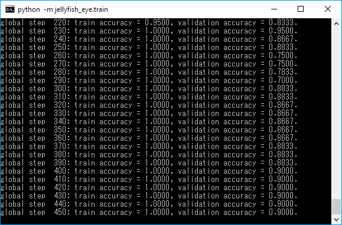

うん、精度90%！ データが少ないことを考慮すれば、かなり良いんじゃないでしょうか？ こんなもんかなーと思ったら、`Ctrl-c`でプログラムを終了してください（`Supervisor`のおかげで途中で止めても再開できますから、ご安心ください）。

なお、GPUを積んでいない私の4年前のおんぼろラップトップPCだとここまで訓練するのに30*分*くらいかかりましたが、NvidiaのGeForce GTX 980 Tiという1年前に10万円で買ったGPUを積んだPCで実験してみたら、30*秒*で終わっちゃいました……。2017年3月現在なら980より圧倒的に速いというGeForce GTX 1080が8万円くらいで買えますので、もし深層学習に興味を持ったならGPUの購入をおすすめします。

あと、学習している間が暇だなーと感じるようでしたら、TensorFlowのツールであるTensorBoardで学習内容を可視化してみてください。TensorBoardは、コマンドラインから`tesnsorboard --logdir=logs`と入力すれば起動できます。コマンドライン上でTensorBoardが起動したら、Webブラウザを開いてURLに`localhost:6006`と入れればオッケー。こうすると、前の項で見ていただいたような畳込み結果や入力画像を見られたり、損失関数がどんどん減っている（学習がどんどん進んでいる）ことが分かるので、あまり退屈しないで済みます。

さて、訓練が終わったので、その結果をサービス化してみると……

[figure not shown]

# おわりに

ほら、深層学習って簡単でしょ？ 本稿のコードをコピー＆ペーストして、データを取得する部分を書き直して、必要に応じてニューラル・ネットワークをチューニングするだけでよいんですから。

多層パーセプトロンや畳み込み、プーリング、ドロップアウトという深層学習で使われる道具についても、数学なしでその概念を理解できました[^7]。概念が分かっているのですから、ニューラル・ネットワークのチューニングは可能なはず[^8]。逆誤差伝播学習法の詳細になると数学が必要なのですけど、TensorFlowが全自動でやってくれるから詳細を理解していなくても問題ないしね[^9]。ほらやっぱり、深層学習って簡単でしょ？

でも、深層学習って画像が何なのかを判断できるるだけなのでは？ データが画像以外だったらどうするの……という皆様からの反論が聞こえてきそうですけど、深層学習は画像以外でも使えるのでご安心ください。私は先日、ひょんなことから「トイレの個室でのスマートフォン使用を、超音波センサー10個の距離情報（トイレで動画を撮るわけにはいきませんもんね）から検知する」システムのプロトタイプを作ったのですけど、適当に取った数人×数分のデータを、以下のニューラル・ネットワークに食わせて学習してみたら、70%を超える精度が出ちゃいました。遊びでやったので作業は止まってますけど、データを増やせば精度が向上して、実用になるんじゃないかな。

```python
def inference():
    outputs = tf.reshape(inputs, (-1, data_sets.history_size, 1, data_sets.channel_size))  # 幅を1にして、1次元データをconvolution2dできるようにします。
    outputs_collection = [tf.contrib.layers.max_pool2d(tf.contrib.layers.convolution2d(outputs, 128, (kernel_size, 1), padding='VALID'), (data_sets.history_size - kernel_size + 1, 1)) for kernel_size in (5, 4, 3, 2)]
    outputs = tf.concat(1, [tf.contrib.layers.flatten(outputs) for outputs in outputs_collection])  # 次元0はバッチなので、次元1でconcatします。
    outputs = tf.contrib.layers.stack(outputs, tf.contrib.layers.fully_connected, (1024, 512))
    outputs = tf.contrib.layers.dropout(outputs, is_training=is_training)

    return tf.contrib.layers.linear(outputs, 2)
```

ちなみに、このニューラル・ネットワークは、「[自然言語処理における畳み込みニューラルネットワークを理解する](http://tkengo.github.io/blog/2016/03/11/understanding-convolutional-neural-networks-for-nlp/)」で引用されている論文（hang, Y., & Wallace, B. (2015). A Sensitivity Analysis of (and Practitioners' Guide to) Convolutional Neural Networks for Sentence Classification）の、文章をカケラも読まずに図だけを見て作りました。深層学習は道具立てが簡単なので、けっこう楽ちんに小難しい論文の内容を活用できちゃうんですな。ほら、やっぱり、深層学習は簡単。

ぜひ、皆様も深層学習してみてください。とても楽しいですよ。

[^1]: 正しくは、深層学習は「その適用方法が定まった分野をやる場合は」とても簡単なだけですけど。再帰型ニューラル・ネットワークの最先端とかは、やたらと難しいです……。
[^2]: 本稿の後半で紹介するTensorFlowの機能面でのメリットとして、自動微分があります。TensorFlowなら、計算グラフを作るだけで、学習に必要となる微分のコードを書かなくてもよいんですよ。私のような数学大嫌いな微分なにそれおいしいのという人間でも、最新の深層学習の計算グラフをただただ書き写せば動いてしまうというわけ。まぁ、Chainerでも、深層学習で一般的に使われる演算についてはライブラリ中に微分のコードが実装されていますから、通常は微分のことなんか考えなくて済みますけど。
[^3]: nVidiaのCUDAに対応したGPUを積んだコンピューターでCUDAとcuDNNがセットアップされている場合は、`pip install tensorflow-gpu`でGPUを使用して高速に動作するバージョンのTensorFlowをセットアップできます。GPU版を使用しても、本稿のコードは全て動作しますのでご安心を（Ubuntu 16.04 ＋ GeForce GTX 980 Tiで動作確認済み）。
[^4]: Chainerは、微分をライブラリ内に実装することでこの問題を解決しています。私のような一般人が作るニューラル・ネットワークなら、TensorFlowと同様に微分と無関係に深層学習できますので、ご安心ください。
[^5]: 遺伝的プログラミングのように、計算式そのものを生成するような学習もありますけど。
[^6]: 深層学習で使うニューラル・ネットワークってのは、微分（劣微分を含む）可能な演算でつながれた計算式にすぎません。だから、生物の脳やニューロンとは関係がないニューラル・ネットワークもあります。最近の再帰ニューラル・ネットワークなんかだと、ニューラルな感じはゼロで、なんでそれで答えを導けるのか全くわからなくて面白いですよ。
[^7]: 再帰型ニューラル・ネットワークについての説明は、ごめんなさい、使い方が定まるまで待ってください……。
[^8]: 数学的に理解している人たちも、結構行き当たりばったりでチューニングしているみたいだしね。
[^9]: 少なくとも私は、本稿に書いたレベルしか理解できていません。でもだいじょーぶ。